# R Notebook

6E1 State three motivating criteria that define information entropy. Try to express each in your own words.

6E2 Suppose a coin is weighted such that, when it is tossed and lands on a table, it comes up with heads 70% of the time. What is the entropy of this coin?

```r
p <- c(0.3, 0.7)
entropy <- -sum(p*log(p))
entropy
```

```
[1] 0.6108643
```

```r
p <- c(0.1, 0.25, 0.25, 0.3)
entropy <- -sum(p*log(p))
entropy
```

```
[1] 1.284598
```

6E4

```r
p <- c(1/3, 1/3, 1/3)
entropy <- -sum(p*log(p))
entropy
```

```
[1] 1.098612
```

6M1 AIC:

DIC:

WAIC:

6M2 Explain the difference between model selection and model averaging. What information is lost under model selection? What information is lost under model averaging?

6M3

When comparing models with an information criterion, why must all models be fit to exactly the same observations? What would happen to the information criterion values, if the models were fit to different numbers of observations? Perform some experiments if you are not sure.

6M4 What happens to the effective number of parameters, as measured by DIC or WAIC, as a prior becomes more concentrated? Why? Perform some experiments, if you are not sure.

6M5 Provide an informal explanation of why informative priors reduce overfitting.

6M6 Provide and information explanation of why overly informative priors result in overfitting.

6H1

```r
library(rethinking)
data(Howell1)
d <- Howell1
d$age <- (d$age - mean(d$age))/ sd(d$age)
d$age2 <- d$age ** 2
d$age3 <- d$age ** 3
d$age4 <- d$age ** 4
d$age5 <- d$age ** 5
d$age6 <- d$age ** 6
set.seed(1000)
i <- sample(1:nrow(d), size = nrow(d) / 2)
d1 <- d[i,]
d2 <- d[-i,]
```

```r
m6H1.1 <- map(
  alist (
    height ~ dnorm(mu, sigma),
    mu <- a + b1*age ,
    a ~ dnorm(0,100),
    b1 ~ dnorm(0,100),
    sigma ~ dunif(0,50)
  ),
  data = d1
)
```

```r
m6H1.2 <- map(
  alist (
    height ~ dnorm(mu, sigma),
    mu <- a + b1*age + b2*age^2 ,
    a ~ dnorm(0,100),
    b1 ~ dnorm(0,100),
    b2 ~ dnorm(0,100),
    sigma ~ dunif(0,50)
  ),
  data = d1
)
```

```r
m6H1.3 <- map(
  alist (
    height ~ dnorm(mu, sigma),
    mu <- a + b1*age + b2*age^2 + b3*age^3 ,
    a ~ dnorm(0,100),
    b1 ~ dnorm(0,100),
    b2 ~ dnorm(0,100),
    b3 ~ dnorm(0,100),
    sigma ~ dunif(0,50)
  ),
  data = d1
)
```

```r
m6H1.4 <- map(
  alist (
    height ~ dnorm(mu, sigma),
    mu <- a + b1*age + b2*age^2 + b3*age^3 + b4*age^4,
    a ~ dnorm(0,100),
    b1 ~ dnorm(0,100),
    b2 ~ dnorm(0,100),
    b3 ~ dnorm(0,100),
    b4 ~ dnorm(0,100),
    sigma ~ dunif(0,50)
  ),
  data = d1
)
```

```r
m6H1.5 <- map(
  alist (
    height ~ dnorm(mu, sigma),
    mu <- a + b1*age + b2*age^2 + b3*age^3 + b4*age^4 + b5*age^5,
    a ~ dnorm(0,100),
    b1 ~ dnorm(0,100),
    b2 ~ dnorm(0,100),
    b3 ~ dnorm(0,100),
    b4 ~ dnorm(0,100),
    b5 ~ dnorm(0,100),
    sigma ~ dunif(0,50)
  ),
  data = d1
)
```

```r
m6H1.6 <- map(
  alist (
    height ~ dnorm(mu, sigma),
    mu <- a + b1*age + b2*age2 + b3*age3 + b4*age4 + b5*age5 + b6*age6,
    a ~ dnorm(0, 100),
    b1 ~ dnorm(0,100),
    b2 ~ dnorm(0,100),
    b3 ~ dnorm(0,100),
    b4 ~ dnorm(0,100),
    b5 ~ dnorm(0,100),
    b6 ~ dnorm(0,100),
    sigma ~ dunif(0,50)
  ),
  data = d1
)
```

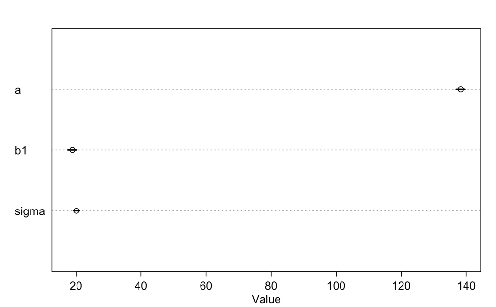

```r
plot(precis(m6H1.1))
```

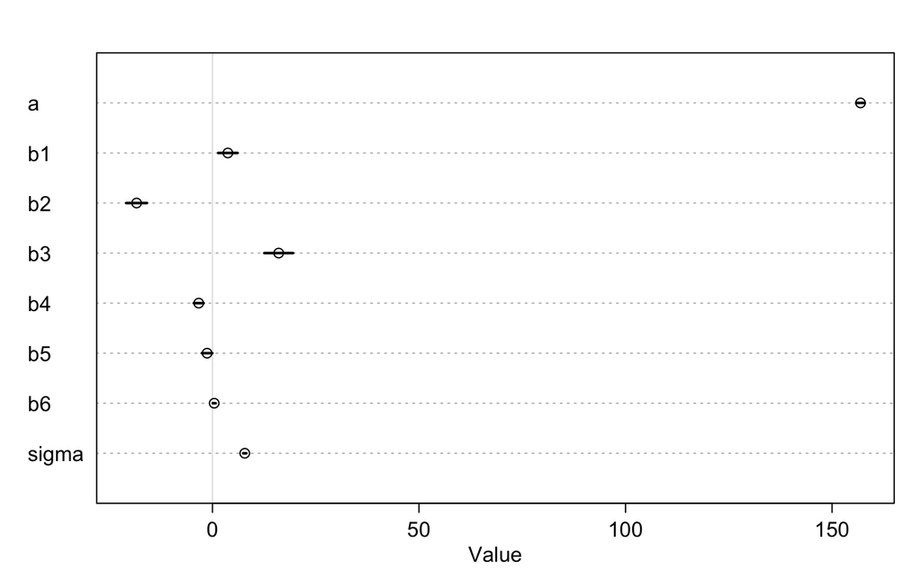

```r
plot(precis(m6H1.6))
```

```r
WAIC(m6H1.1)
```

```
Constructing posterior predictions
```

[output not shown]

```r
WAIC(m6H1.2)
```

```
Constructing posterior predictions
```

[output not shown]

```r
(models <- compare(m6H1.1,m6H1.2,m6H1.3,m6H1.4,m6H1.5,m6H1.6))
```

```
         WAIC pWAIC dWAIC weight    SE   dSE
m6H1.4 1926.1   5.6   0.0   0.57 25.36    NA
m6H1.6 1928.0   7.5   1.9   0.22 25.09  2.90
m6H1.5 1928.1   6.7   2.0   0.21 25.51  1.08
m6H1.3 1952.7   5.6  26.6   0.00 24.24 10.88
m6H1.2 2150.2   5.3 224.1   0.00 22.68 26.76
m6H1.1 2395.7   3.6 469.6   0.00 23.02 31.08
```

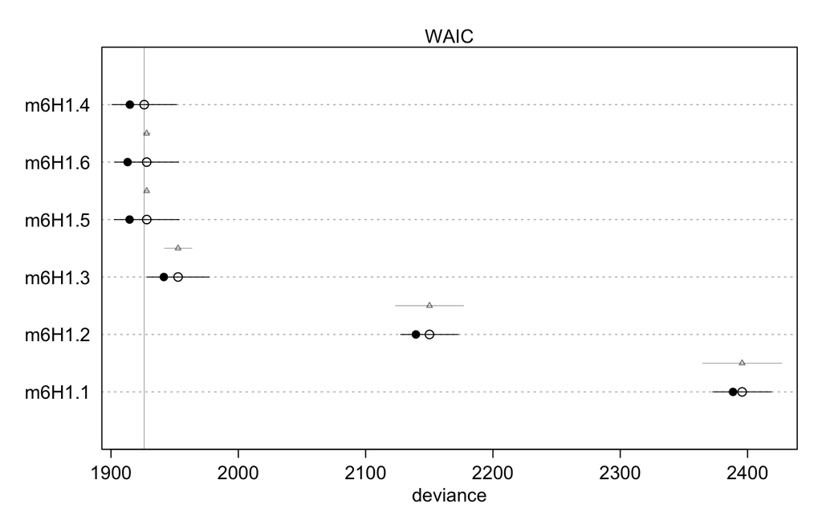

```r
plot(models)
```